# The Journey to and from University

This report will be going over various factors in a trip to or from university

## What’s going on with this data?

This data is being collected by myself as well as some friends of mine in order to get a larger variety of data.

It will be Looking at the journey to or from university everyday. It is collecting how you got to/from uni, how long it took, and some other data depending on how you got there.

## Plot time!

This plot shows the different trip durations (in decimal hours), separated into the transportation type and the mean of each category

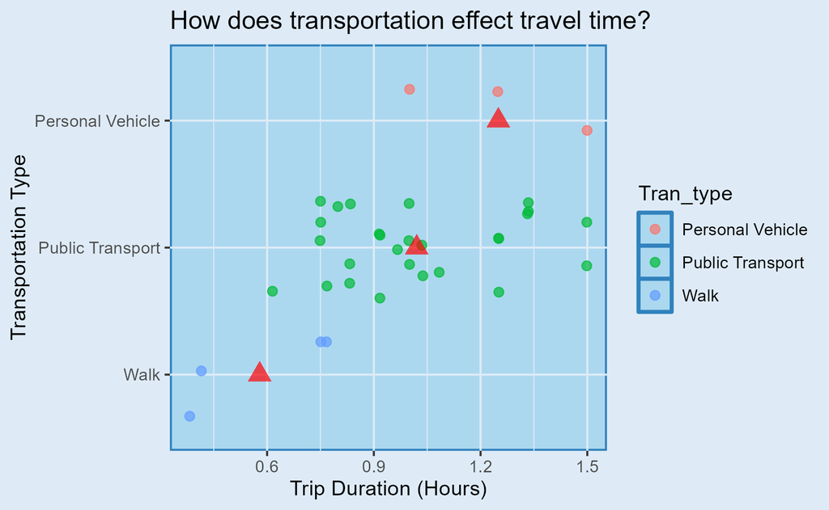

This also shows the difference between the different transportation types, as there is far greater people who took Public Transport

## Even more plots!!!

This next plot shows the correlation between the time of day (hours), and on average how full the first bus/train is.

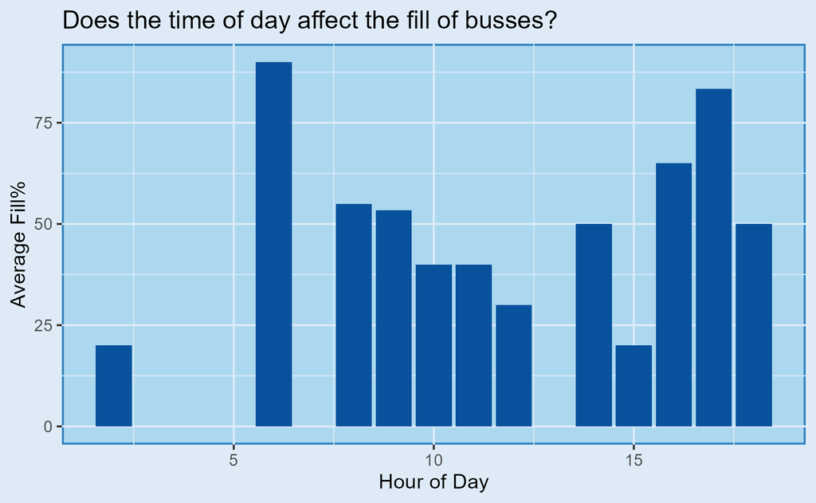

Note that there seems to be spikes around 6AM and 5PM, However, 6AM only has one data point so should be ignored.

This is likely due to work/uni ending around those times for most people.

## Even more plots?

This plot looks at how the number of busses/trains taken effects the Journey time

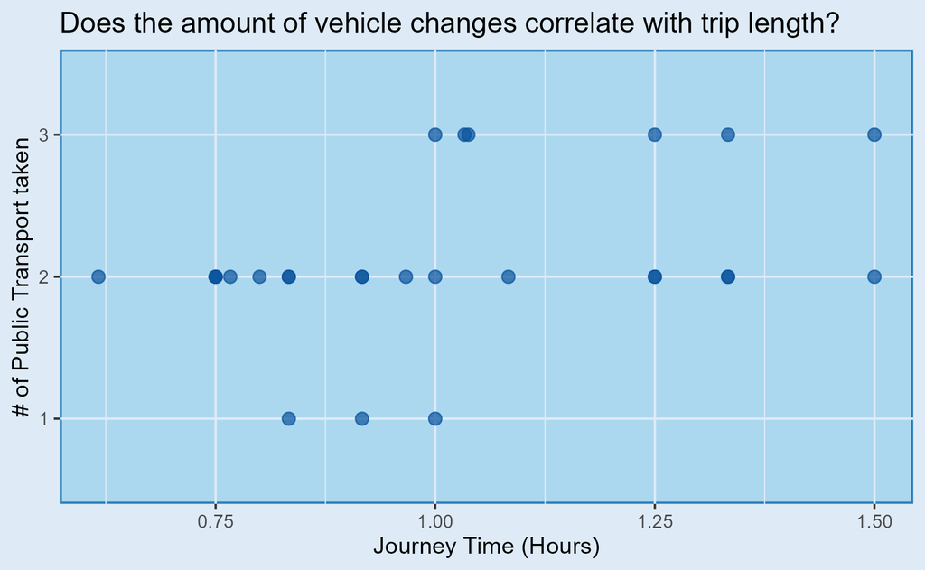

A Plot showing how the Number of transportations taken affects journey time

## Ok last one

This final plot looks at comparing the hour of submission and the hour marked as arrival. This gives us an idea of whether they submitted it shortly after arriving or at a later time.

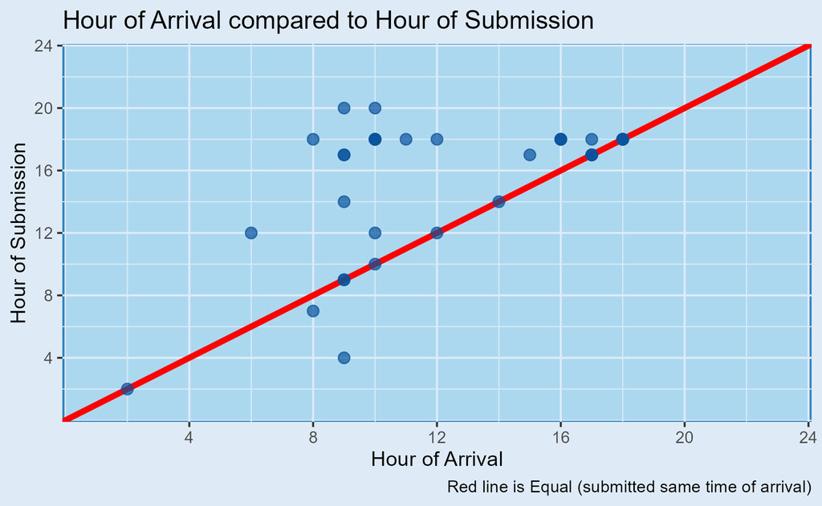

Note that the ones submitted before arrival were likely submitted the day after.